# Billboard Top 100 Hit Prediction

# Loading Libraries

`r`r library(NLP) library(tm) library(SnowballC) library(wordcloud) library(MASS) library(caTools) library(dplyr) library(rpart) library(rpart.plot) library(randomForest) library(caret) library(corpus) library(qdapRegex) library(gbm) library(boot) library(dplyr) library(ggplot2) library(gplots) library(GGally) library(caTools) library(car) library(ROCR) library(pROC) library(mlbench) library(caretEnsemble) library(glmnet)

# Loading Data

`r`r songs = read.csv(../data/songs_complete_data.csv, stringsAsFactors=FALSE) songs = songs %>% filter(Release_Year >= 2000, Release_Year < 2019)

songs$X = NULL songs$Artist = NULL songs$Title = NULL songs$URI = NULL songs$Release_Year = NULL

`r`r all_lyrics = songs$lyrics top100 = songs$Top100

songs$lyrics = NULL songs$Top100 = NULL

songs$Danceability = scale(songs$Danceability) songs$Energy = scale(songs$Energy) songs$Loudness = scale(songs$Loudness) songs$Speechiness = scale(songs$Speechiness) songs$Acousticness = scale(songs$Acousticness) songs$Instrumentalness = scale(songs$Instrumentalness) songs$Liveness = scale(songs$Liveness) songs$Valence = scale(songs$Valence) songs$Tempo = scale(songs$Tempo) songs$Duration = scale(songs$Duration)

songs$Key = as.factor(songs$Key) songs$Mode = as.factor(songs$Mode) songs$Time_Signature = as.factor(songs$Time_Signature) songs$explicit = as.factor(songs$explicit) songs$Genre = as.factor(songs$Genre)

# Convert every categorical variable to numerical using dummy variable

dmy <- dummyVars( ~ ., data=songs, fullRank = TRUE) songs <- data.frame(predict(dmy, newdata=songs))

# Add back lyrics and dependent variable

songs$Lyrics = all_lyrics songs$Top100 = as.factor(top100)

# NLP: Bag of Words

`r`r set.seed(123)

corpus_lyrics = Corpus(VectorSource(songs$Lyrics))

corpus_lyrics = tm_map(corpus_lyrics, tolower)

```
transformation drops documents
```

`r`r corpus_lyrics = tm_map(corpus_lyrics, removeNumbers)

```
transformation drops documents
```

`r`r corpus_lyrics = tm_map(corpus_lyrics, removeWords, stopwords(‘english’))

```
transformation drops documents
```

`r`r corpus_lyrics = tm_map(corpus_lyrics, removePunctuation)

```
transformation drops documents
```

`r`r corpus_lyrics = tm_map(corpus_lyrics, stemDocument)

```
transformation drops documents
```

`r`r for (i in seq(corpus_lyrics)) { corpus_lyrics[[i]] <- gsub(‘[^a-zA-Z|[:blank:]]’, \, corpus_lyrics[[i]]) }

corpus_lyrics = tm_map(corpus_lyrics, stemDocument)

```
transformation drops documents
```

`r`r corpus_lyrics = tm_map(corpus_lyrics, removeWords, stopwords(‘english’))

```
transformation drops documents
```

`r`r corpus_lyrics = tm_map(corpus_lyrics, stripWhitespace)

```
transformation drops documents
```

`r`r frq_lyrics = DocumentTermMatrix(corpus_lyrics) sparse_lyrics = removeSparseTerms(frq_lyrics, 0.93) sparse_lyrics

```
<<DocumentTermMatrix (documents: 7086, terms: 82)>>
Non-/sparse entries: 81212/499840
Sparsity           : 86%
Maximal term length: 7
Weighting          : term frequency (tf)
```

`r`r lyric_words = as.data.frame(as.matrix(sparse_lyrics)) colnames(lyric_words) = make.names(colnames(lyric_words))

songs = cbind(songs, lyric_words) songs$Lyrics = NULL

# Building ML Models

`r`r # helper functions to calculate accuracy, TPR, and FPR

tableAccuracy <- function(test, pred) { t = table(test, pred) a = sum(diag(t))/length(test) return(a) }

tableTPR <- function(label, pred) { t = table(label, pred) return(t[2,2]/(t[2,1] + t[2,2])) }

tableFPR <- function(label, pred) { t = table(label, pred) return(t[1,2]/(t[1,1] + t[1,2])) }

# Train-Test Split

`r`r spl = sample.split(songs$Top100, SplitRatio = 0.75) train = songs %>% filter(spl == TRUE) test = songs %>% filter(spl == FALSE)

levels(train$Top100) <- make.names(levels(factor(train$Top100))) levels(test$Top100) <- make.names(levels(factor(test$Top100)))

# make model matrices

train.mm = as.data.frame(model.matrix(Top100 ~ . + 0, data=train)) test.mm = as.data.frame(model.matrix(Top100 ~ . + 0, data=test))

# Model 0: Baseline Model

`r`r table(train$Top100) # most frequent is Top 100

```
  X0   X1
4244 1071
```

`r`r table(test$Top100) # baseline: predict always Top 100

```
  X0   X1
1414  357
```

`r`r baseline_accuracy = 1414/(1414+357) # 0.7984

# Model 1: Logistic Regression

`r`r set.seed(123)

log_model = glm(Top100 ~ .-Time_Signature.4-Genre.rap, data = train, family = )

```
glm.fit: fitted probabilities numerically 0 or 1 occurred
```

`r`r vif(log_model) # Removed Time_Signature.4 and Genre.rap because of high VIF score

```
    Danceability           Energy            Key.1            Key.2            Key.3            Key.4
        1.750265         3.156503         2.069126         1.757987         1.255771         1.672249
           Key.5            Key.6            Key.7            Key.8            Key.9           Key.10
        1.816867         1.624020         1.883976         1.764143         1.741479         1.649592
          Key.11         Loudness           Mode.1      Speechiness     Acousticness Instrumentalness
        1.854551         2.272408         1.163654         1.578301         1.558666         1.091477
        Liveness          Valence            Tempo         Duration Time_Signature.3 Time_Signature.5
        1.089982         1.534744         1.126713         1.195603         1.074349         1.080766
      explicit.1  Genre.classical    Genre.country        Genre.edm       Genre.jazz      Genre.metal
        1.597559         1.000000         1.727118         1.000000         1.000000         1.380208
       Genre.pop     Genre.reggae       Genre.rock             away              day             even
        2.539283         1.063066         1.646879         1.100275         1.106146         1.081739
         everyth              got             hold             just             keep             know
        1.054229         1.214837         1.061757         1.140728         1.059556         1.133981
            life             look             mind              one            right            thing
        1.119564         1.078310         1.053087         1.086837         1.285592         1.068527
            time              tri             will             back             come              eye
        1.138971         1.063083         1.072653         1.110349         1.097244         1.040491
           gonna             leav            night              say             take             talk
        1.124322         1.056788         1.092623         1.084138         1.076573         1.064598
             get             girl            light            littl             make              see
        1.191111         1.138687         1.100858         1.076027         1.094165         1.136643
            show             turn             wait              way             call              can
        1.084594         1.074629         1.062327         1.079848         1.086814         1.084537
            like              now              run             caus             fuck             give
        1.204550         1.306752         1.073115         1.098619         1.369106         1.104927
           never             tell             head           better              boy             ever
        1.140973         1.079196         1.054946         1.050342         1.064976         1.056671
            feel             live             love             stay             want            world
        1.117041         1.080929         1.119509         1.046241         1.065403         1.073154
             put            think            alway             need           around              let
        1.081820         1.068099         1.080340         1.086926         1.078329         1.110938
            long           someth            everi            still             babi             hand
        1.053498         1.055194         1.134520         1.083711         1.120998         1.057481
            shit             yeah            wanna             said            heart             good
        1.295843         1.119577         1.124447         1.063446         1.072423         1.094301
             que             aint            bitch              man            money            gotta
        1.066418         1.213502         1.378479         1.103977         1.127651         1.113965
           nigga
        1.421344
```

`r`r summary(log_model)

```
Call:
glm(formula = Top100 ~ . - Time_Signature.4 - Genre.rap, family = \binomial\,
    data = train)

Deviance Residuals:
    Min       1Q   Median       3Q      Max
-2.7050  -0.6332  -0.3619  -0.0329   3.6600

Coefficients:
                   Estimate Std. Error z value Pr(>|z|)
(Intercept)       -3.223630   0.210584 -15.308  < 2e-16 ***
Danceability       0.054971   0.055638   0.988 0.323148
Energy            -0.468877   0.082193  -5.705 1.17e-08 ***
Key.1              0.154599   0.170635   0.906 0.364925
Key.2              0.186744   0.185288   1.008 0.313525
Key.3              0.082839   0.288697   0.287 0.774157
Key.4              0.225679   0.198821   1.135 0.256339
Key.5              0.206135   0.187369   1.100 0.271266
Key.6             -0.024233   0.200602  -0.121 0.903848
Key.7              0.155776   0.176837   0.881 0.378369
Key.8              0.438387   0.185280   2.366 0.017978 *
Key.9              0.160271   0.188782   0.849 0.395894
Key.10             0.108322   0.202456   0.535 0.592620
Key.11             0.192380   0.185570   1.037 0.299877
Loudness           0.581086   0.083252   6.980 2.95e-12 ***
Mode.1             0.091120   0.088192   1.033 0.301508
Speechiness       -0.054340   0.050735  -1.071 0.284146
Acousticness      -0.544259   0.066753  -8.153 3.54e-16 ***
Instrumentalness  -0.857873   0.179281  -4.785 1.71e-06 ***
Liveness          -0.167714   0.044712  -3.751 0.000176 ***
Valence            0.159106   0.051324   3.100 0.001935 **
Tempo             -0.101132   0.043010  -2.351 0.018704 *
Duration           0.480716   0.046144  10.418  < 2e-16 ***
Time_Signature.3  -0.228689   0.268571  -0.852 0.394491
Time_Signature.5   0.453932   0.327870   1.384 0.166210
explicit.1         0.255848   0.100299   2.551 0.010746 *
Genre.classical  -10.928023 634.716684  -0.017 0.986263
Genre.country      1.571513   0.216307   7.265 3.73e-13 ***
Genre.edm        -14.926421 371.501732  -0.040 0.967951
Genre.jazz       -14.921590 429.071347  -0.035 0.972258
```

[output cut: 81 more lines]

```
bitch             -0.010591   0.048077  -0.220 0.825643
man                0.058960   0.052432   1.124 0.260803
money             -0.013314   0.053357  -0.250 0.802955
gotta              0.062774   0.061659   1.018 0.308636
nigga             -0.043042   0.041458  -1.038 0.299173
---
Signif. codes:  0 ‘***’ 0.001 ‘**’ 0.01 ‘*’ 0.05 ‘.’ 0.1 ‘ ’ 1

(Dispersion parameter for binomial family taken to be 1)

    Null deviance: 5341.4  on 5314  degrees of freedom
Residual deviance: 4030.2  on 5199  degrees of freedom
AIC: 4262.2

Number of Fisher Scoring iterations: 16
```

`r`r predict_log = predict(log_model, newdata = test, type = ) table(test$Top100, predict_log > 0.5)

```
     FALSE TRUE
  X0  1329   85
  X1   254  103
```

`r`r tableAccuracy(test$Top100, predict_log > 0.5) # 0.8006776

```
[1] 0.8085827
```

`r`r tableTPR(test$Top100, predict_log > 0.5) # 0.2464986

```
[1] 0.2885154
```

`r`r tableFPR(test$Top100, predict_log > 0.5) # 0.05940594

```
[1] 0.06011315
```

`r`r # Calculate ROC curve rocr.log.pred <- prediction(predict_log, test$Top100) logPerformance <- performance(rocr.log.pred, , ) plot(logPerformance, colorize = TRUE) abline(0, 1)

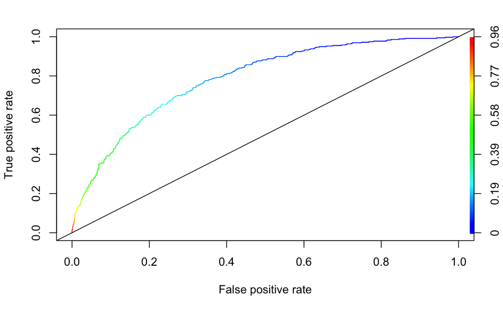

`r`r

as.numeric(performance(rocr.log.pred, )@y.values) # AUC = 0.771259

```
[1] 0.7859144
```

# Model 2: Improved Logistic Regression

`r`r set.seed(123)

#Selecting only significiant features (excluding lyrics) log_model = glm(Top100 ~ .-Danceability-Key.1-Key.2-Key.3-Key.4-Key.5-Key.6-Key.7-Key.9-Key.10-Key.11- Mode.1-Speechiness-Time_Signature.3-Time_Signature.4-Time_Signature.5-Genre.classical- Genre.edm-Genre.jazz-Genre.rap-Genre.metal-Genre.reggae-Genre.rock, data = train, family = ) vif(log_model)

```
          Energy            Key.8         Loudness     Acousticness Instrumentalness         Liveness
        2.867216         1.026624         2.241970         1.506119         1.081931         1.069540
         Valence            Tempo         Duration       explicit.1    Genre.country        Genre.pop
        1.269367         1.071243         1.168394         1.468134         1.315645         1.459014
            away              day             even          everyth              got             hold
        1.084350         1.095125         1.074891         1.050365         1.189240         1.054977
            just             keep             know             life             look             mind
        1.136407         1.050490         1.126664         1.102090         1.071069         1.048666
             one            right            thing             time              tri             will
        1.080079         1.273906         1.058117         1.132120         1.059680         1.064097
            back             come              eye            gonna             leav            night
        1.095863         1.089032         1.035262         1.116480         1.051073         1.084389
             say             take             talk              get             girl            light
        1.081508         1.071855         1.056286         1.182808         1.131271         1.089298
           littl             make              see             show             turn             wait
        1.063307         1.087278         1.123523         1.072569         1.065966         1.056213
             way             call              can             like              now              run
        1.074194         1.077861         1.087327         1.189647         1.290148         1.055018
            caus             fuck             give            never             tell             head
        1.093742         1.374975         1.098106         1.135501         1.074448         1.050069
          better              boy             ever             feel             live             love
        1.054483         1.059463         1.052227         1.110685         1.074172         1.120511
            stay             want            world              put            think            alway
        1.041264         1.060431         1.058314         1.077027         1.060051         1.071998
            need           around              let             long           someth            everi
        1.074286         1.073353         1.101381         1.051767         1.048996         1.127020
           still             babi             hand             shit             yeah            wanna
        1.075261         1.110561         1.054084         1.275862         1.103787         1.118221
            said            heart             good              que             aint            bitch
        1.057164         1.067639         1.087169         1.050323         1.185045         1.364639
             man            money            gotta            nigga
        1.098829         1.118348         1.107590         1.384963
```

`r`r summary(log_model)

```
Call:
glm(formula = Top100 ~ . - Danceability - Key.1 - Key.2 - Key.3 -
    Key.4 - Key.5 - Key.6 - Key.7 - Key.9 - Key.10 - Key.11 -
    Mode.1 - Speechiness - Time_Signature.3 - Time_Signature.4 -
    Time_Signature.5 - Genre.classical - Genre.edm - Genre.jazz -
    Genre.rap - Genre.metal - Genre.reggae - Genre.rock, family = \binomial\,
    data = train)

Deviance Residuals:
    Min       1Q   Median       3Q      Max
-2.6311  -0.6309  -0.3691  -0.0642   3.6718

Coefficients:
                  Estimate Std. Error z value Pr(>|z|)
(Intercept)      -3.290356   0.125571 -26.203  < 2e-16 ***
Energy           -0.505680   0.078016  -6.482 9.07e-11 ***
Key.8             0.316210   0.140939   2.244 0.024858 *
Loudness          0.603382   0.082498   7.314 2.60e-13 ***
Acousticness     -0.560965   0.065364  -8.582  < 2e-16 ***
Instrumentalness -0.871902   0.178580  -4.882 1.05e-06 ***
Liveness         -0.169718   0.044121  -3.847 0.000120 ***
Valence           0.166554   0.046509   3.581 0.000342 ***
Tempo            -0.114694   0.041684  -2.752 0.005932 **
Duration          0.462715   0.044993  10.284  < 2e-16 ***
explicit.1        0.326070   0.095987   3.397 0.000681 ***
Genre.country     1.827696   0.189164   9.662  < 2e-16 ***
Genre.pop         0.763797   0.096540   7.912 2.54e-15 ***
away              0.191876   0.066029   2.906 0.003661 **
day               0.026725   0.064642   0.413 0.679293
even              0.115958   0.081047   1.431 0.152500
everyth           0.057920   0.079852   0.725 0.468244
got               0.055326   0.027885   1.984 0.047246 *
hold             -0.037451   0.073731  -0.508 0.611494
just              0.016546   0.030549   0.542 0.588077
keep              0.018871   0.055943   0.337 0.735875
know              0.074931   0.024328   3.080 0.002070 **
life              0.114251   0.065540   1.743 0.081295 .
look              0.019582   0.052619   0.372 0.709786
mind             -0.194760   0.089387  -2.179 0.029344 *
one               0.083628   0.040485   2.066 0.038860 *
```

[output cut: 64 more lines]

```
bitch            -0.005356   0.047867  -0.112 0.910910
man               0.064434   0.052293   1.232 0.217880
money            -0.010091   0.053211  -0.190 0.849596
gotta             0.067677   0.061349   1.103 0.269960
nigga            -0.027726   0.040550  -0.684 0.494133
---
Signif. codes:  0 ‘***’ 0.001 ‘**’ 0.01 ‘*’ 0.05 ‘.’ 0.1 ‘ ’ 1

(Dispersion parameter for binomial family taken to be 1)

    Null deviance: 5341.4  on 5314  degrees of freedom
Residual deviance: 4063.9  on 5220  degrees of freedom
AIC: 4253.9

Number of Fisher Scoring iterations: 7
```

`r`r predict_log = predict(log_model, newdata = test, type = ) table(test$Top100, predict_log > 0.5)

```
     FALSE TRUE
  X0  1328   86
  X1   250  107
```

`r`r tableAccuracy(test$Top100, predict_log > 0.5) # 0.8051948

```
[1] 0.8102767
```

`r`r tableTPR(test$Top100, predict_log > 0.5) # 0.2605042

```
[1] 0.2997199
```

`r`r tableFPR(test$Top100, predict_log > 0.5) # 0.0572843

```
[1] 0.06082037
```

`r`r # Calculate ROC curve rocr.log.pred <- prediction(predict_log, test$Top100) logPerformance <- performance(rocr.log.pred, , ) plot(logPerformance, colorize = TRUE) abline(0, 1)

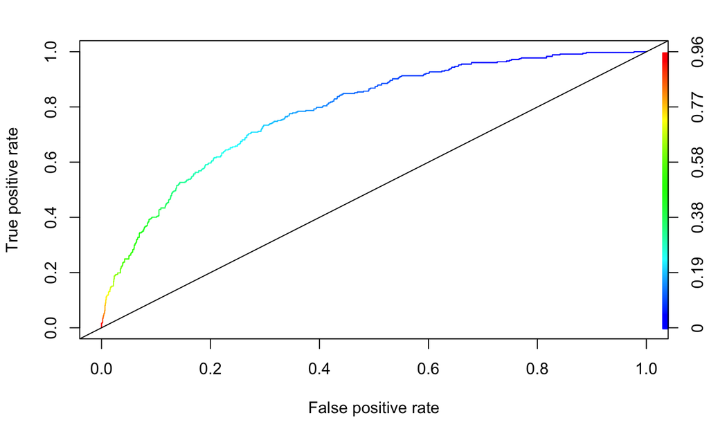

`r`r

as.numeric(performance(rocr.log.pred, )@y.values) # AUC = 0.7702111

```
[1] 0.7847674
```

# Model 3: LDA

`r`r set.seed(123)

lda_model = lda(Top100 ~ .-Danceability-Key.1-Key.2-Key.3-Key.4-Key.5-Key.6-Key.7-Key.9-Key.10-Key.11- Mode.1-Speechiness-Time_Signature.3-Time_Signature.4-Time_Signature.5-Genre.classical- Genre.edm-Genre.jazz-Genre.rap-Genre.metal-Genre.reggae-Genre.rock, data = train, family = )

predict_lda = predict(lda_model, newdata=test) predict_lda$class[1:10]

```
 [1] X0 X0 X0 X0 X0 X0 X0 X0 X0 X0
Levels: X0 X1
```

`r`r predict_lda$posterior[1:10, ]

```
          X0         X1
1  0.9085412 0.09145878
2  0.9352845 0.06471550
3  0.9337743 0.06622575
4  0.8272135 0.17278650
5  0.9578583 0.04214167
6  0.9090377 0.09096235
7  0.8932790 0.10672102
8  0.9351087 0.06489132
9  0.9657162 0.03428378
10 0.8872713 0.11272872
```

`r`r predict_lda_probs <- predict_lda$posterior[,2]

table(test$Top100, predict_lda_probs > 0.5)

```
     FALSE TRUE
  X0  1326   88
  X1   257  100
```

`r`r tableAccuracy(test$Top100, predict_lda_probs > 0.5) # 0.8006776

```
[1] 0.8051948
```

`r`r tableTPR(test$Top100, predict_lda_probs > 0.5) # 0.254902

```
[1] 0.280112
```

`r`r tableFPR(test$Top100, predict_lda_probs > 0.5) # 0.06152758

```
[1] 0.06223479
```

`r`r # Calculate ROC curve rocr.lda.pred <- prediction(predict_lda_probs, test$Top100) ldaPerformance <- performance(rocr.lda.pred, , ) plot(ldaPerformance, colorize = TRUE) abline(0, 1)

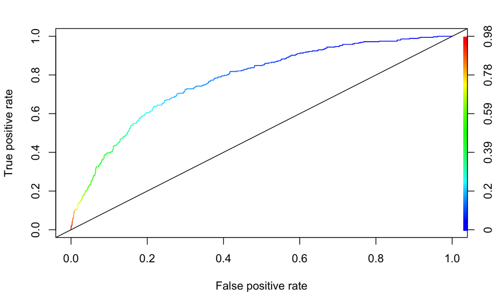

`r`r

as.numeric(performance(rocr.lda.pred, )@y.values) # AUC = 0.7580379

```
[1] 0.7739551
```

# Model 4: 10-CV CART

`r`r set.seed(123)

train_cart = train(Top100 ~ .-Danceability-Key.1-Key.2-Key.3-Key.4-Key.5-Key.6-Key.7-Key.9-Key.10-Key.11- Mode.1-Speechiness-Time_Signature.3-Time_Signature.4-Time_Signature.5-Genre.classical- Genre.edm-Genre.jazz-Genre.rap-Genre.metal-Genre.reggae-Genre.rock, data = train, method = , metric = ‘Accuracy’, tuneGrid = data.frame(cp=seq(0, 0.2, 0.002)), trControl = trainControl(method=, number=10))

cart_model = train_cart$finalModel prp(cart_model) # CART visualization

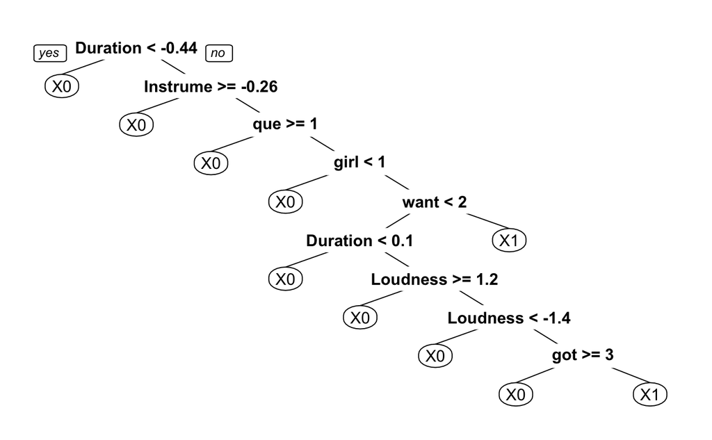

`r`r

predict_cart = predict(cart_model, newdata = test, type=‘class’) table(test$Top100, predict_cart)

```
    predict_cart
       X0   X1
  X0 1381   33
  X1  313   44
```

`r`r tableAccuracy(test$Top100, predict_cart) # 0.8046302

```
[1] 0.8046302
```

`r`r tableTPR(test$Top100, predict_cart) # 0.1232493

```
[1] 0.1232493
```

`r`r tableFPR(test$Top100, predict_cart) # 0.02333805

```
[1] 0.02333805
```

`r`r #Calculate ROC curve cart_probs = predict(cart_model, newdata = test, type=‘prob’) rocCurve.cart <- roc(test$Top100, cart_probs[,1])

`r`r #plot the ROC curve plot(rocCurve.cart, col=c(4))

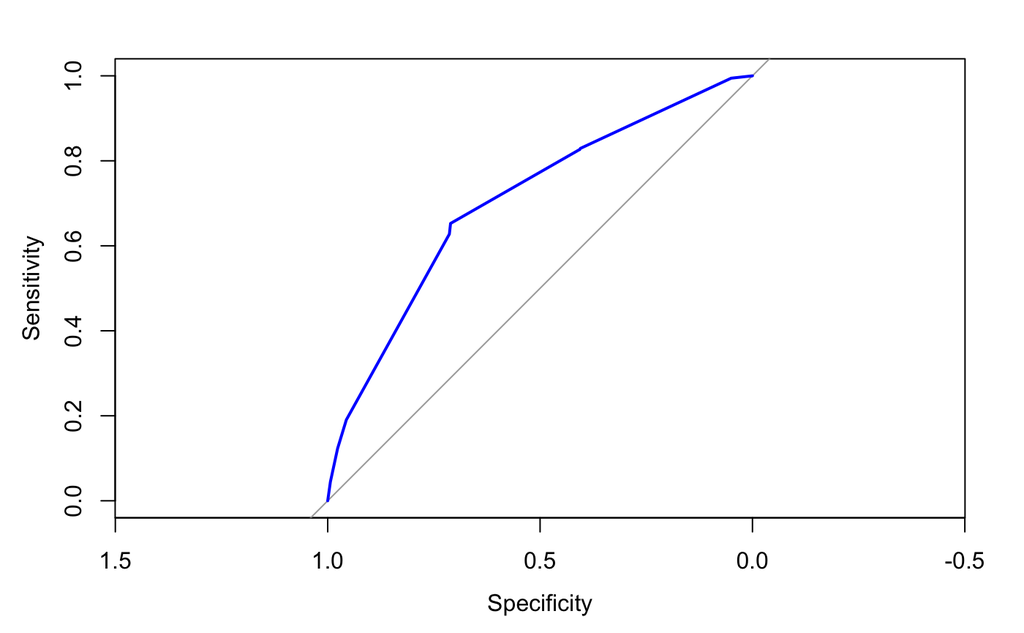

`r`r auc(rocCurve.cart) # 0.7057

```
Area under the curve: 0.7057
```

# Model 5: Random Forest (default)

`r`r set.seed(123)

# (Takes about 3 min to run)

rf_model = randomForest(Top100 ~ .-Danceability-Key.1-Key.2-Key.3-Key.4-Key.5-Key.6-Key.7-Key.9-Key.10-Key.11- Mode.1-Speechiness-Time_Signature.3-Time_Signature.4-Time_Signature.5-Genre.classical- Genre.edm-Genre.jazz-Genre.rap-Genre.metal-Genre.reggae-Genre.rock, data = train)

predict_rf = predict(rf_model, newdata = test) table(test$Top100, predict_rf)

```
    predict_rf
       X0   X1
  X0 1377   37
  X1  295   62
```

`r`r tableAccuracy(test$Top100, predict_rf) # 0.8125353

```
[1] 0.8125353
```

`r`r tableTPR(test$Top100, predict_rf) # 0.1736695

```
[1] 0.1736695
```

`r`r tableFPR(test$Top100, predict_rf) # 0.0261669

```
[1] 0.0261669
```

`r`r #Calculate ROC curve rf_probs = predict(rf_model, newdata = test, type=‘prob’) rocCurve.rf <- roc(test$Top100, rf_probs[,1])

`r`r #plot the ROC curve plot(rocCurve.rf, col=c(4))

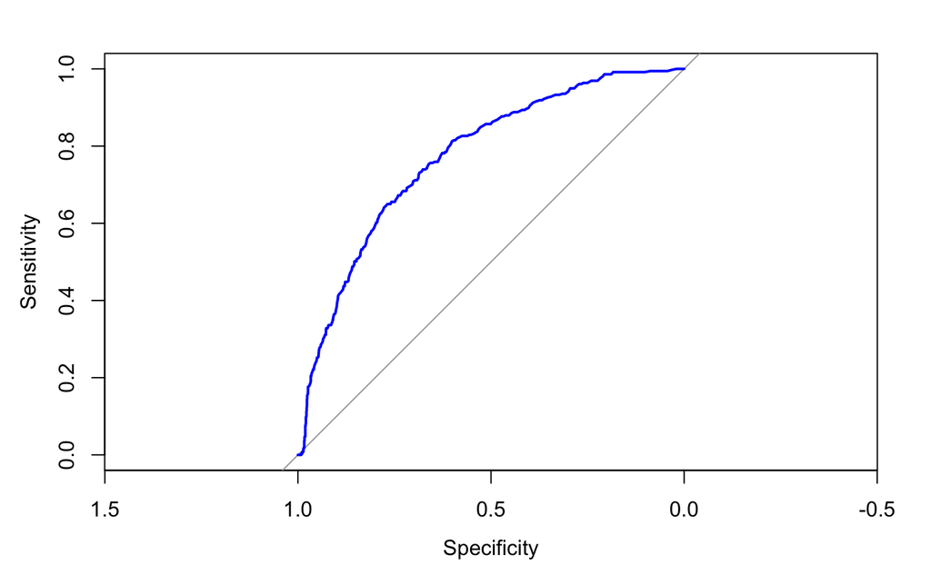

`r`r auc(rocCurve.rf) # 0.7731

```
Area under the curve: 0.7731
```

# Model 6: Bagging

`r`r set.seed(123)

bag_model <- randomForest(x = train.mm, y = train$Top100, mtry = 71, nodesize = 5, ntree = 500)

predict_bag <- predict(bag_model, newdata = test.mm) table(test$Top100, predict_bag)

```
    predict_bag
       X0   X1
  X0 1341   73
  X1  250  107
```

`r`r tableAccuracy(test$Top100, predict_bag) # 0.8068888

```
[1] 0.8176172
```

`r`r tableTPR(test$Top100, predict_bag) # 0.2605042

```
[1] 0.2997199
```

`r`r tableFPR(test$Top100, predict_bag) # 0.05516266

```
[1] 0.05162659
```

`r`r #Calculate ROC curve bagging_probs = predict(bag_model, newdata = test, type=‘prob’) rocCurve.bagging <- roc(test$Top100, bagging_probs[,1])

`r`r #plot the ROC curve plot(rocCurve.bagging, col=c(4))

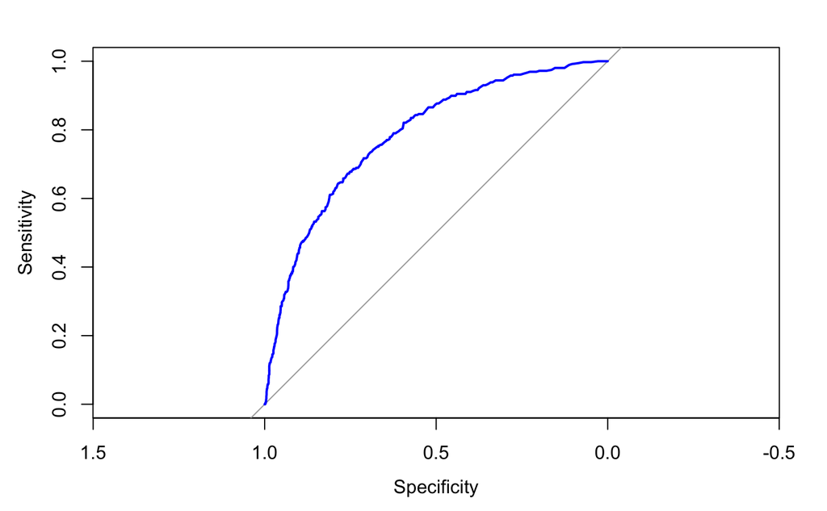

`r`r auc(rocCurve.bagging) # 0.7759

```
Area under the curve: 0.7846
```

# Model 7: 10-CV KNN

`r`r set.seed(123)

objControl <- trainControl(method=, number=10, classProbs=TRUE, summaryFunction=twoClassSummary)

train_knn <- train(Top100 ~ .-Danceability-Key.1-Key.2-Key.3-Key.4-Key.5-Key.6-Key.7-Key.9-Key.10-Key.11- Mode.1-Speechiness-Time_Signature.3-Time_Signature.4-Time_Signature.5-Genre.classical- Genre.edm-Genre.jazz-Genre.rap-Genre.metal-Genre.reggae-Genre.rock, data = train, method = , trControl = objControl, tuneLength = 20)

```
The metric \Accuracy\ was not in the result set. ROC will be used instead.
```

`r`r knnPredict <- predict(train_knn, newdata = test) table(test$Top100, knnPredict)

```
    knnPredict
       X0   X1
  X0 1413    1
  X1  352    5
```

`r`r tableAccuracy(test$Top100, knnPredict) # 0.8006776

```
[1] 0.8006776
```

`r`r tableTPR(test$Top100, knnPredict) # 0.01680672

```
[1] 0.0140056
```

`r`r tableFPR(test$Top100, knnPredict) # 0.001414427

```
[1] 0.0007072136
```

`r`r # Calculate ROC curve knn_probs = predict(train_knn, newdata = test, type=‘prob’) rocCurve.knn <- roc(test$Top100, knn_probs[,1])

`r`r #plot the ROC curve plot(rocCurve.knn, col=c(4))

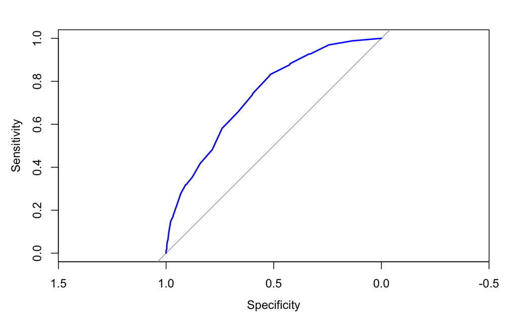

`r`r auc(rocCurve.knn) # 0.7266

```
Area under the curve: 0.7362
```

# Model 8: Stacking (Logistic + CART + LDA)

`r`r set.seed(123)

# create submodels

control <- trainControl(method=, number=10, repeats=3, savePredictions=TRUE, classProbs=TRUE) algorithmList <- c(‘lda’, ‘rpart’, ‘glm’)

models <- caretList(Top100 ~ .-Danceability-Key.1-Key.2-Key.3-Key.4-Key.5-Key.6-Key.7-Key.9-Key.10-Key.11- Mode.1-Speechiness-Time_Signature.3-Time_Signature.4-Time_Signature.5-Genre.classical- Genre.edm-Genre.jazz-Genre.rap-Genre.metal-Genre.reggae-Genre.rock, data=train, trControl=control, methodList=algorithmList)

```
x$savePredictions == TRUE is depreciated. Setting to 'final' instead.indexes not defined in trControl.  Attempting to set them ourselves, so each model in the ensemble will have the same resampling indexes.
```

`r`r results <- resamples(models) summary(results)

```
Call:
summary.resamples(object = results)

Models: lda, rpart, glm
Number of resamples: 30

Accuracy
           Min.   1st Qu.    Median      Mean   3rd Qu.      Max. NA's
lda   0.7909605 0.8098822 0.8120301 0.8136727 0.8206215 0.8421053    0
rpart 0.7758945 0.7948234 0.7984934 0.7989338 0.8041431 0.8139098    0
glm   0.7819549 0.8058317 0.8137345 0.8148015 0.8243879 0.8439850    0

Kappa
           Min.   1st Qu.    Median      Mean   3rd Qu.      Max. NA's
lda   0.1977352 0.2543996 0.2917271 0.2924032 0.3164934 0.4095606    0
rpart 0.0000000 0.1031316 0.1580141 0.1419699 0.1913243 0.2767406    0
glm   0.1981081 0.2530975 0.2794000 0.2900432 0.3200187 0.4141280    0
```

`r`r dotplot(results)

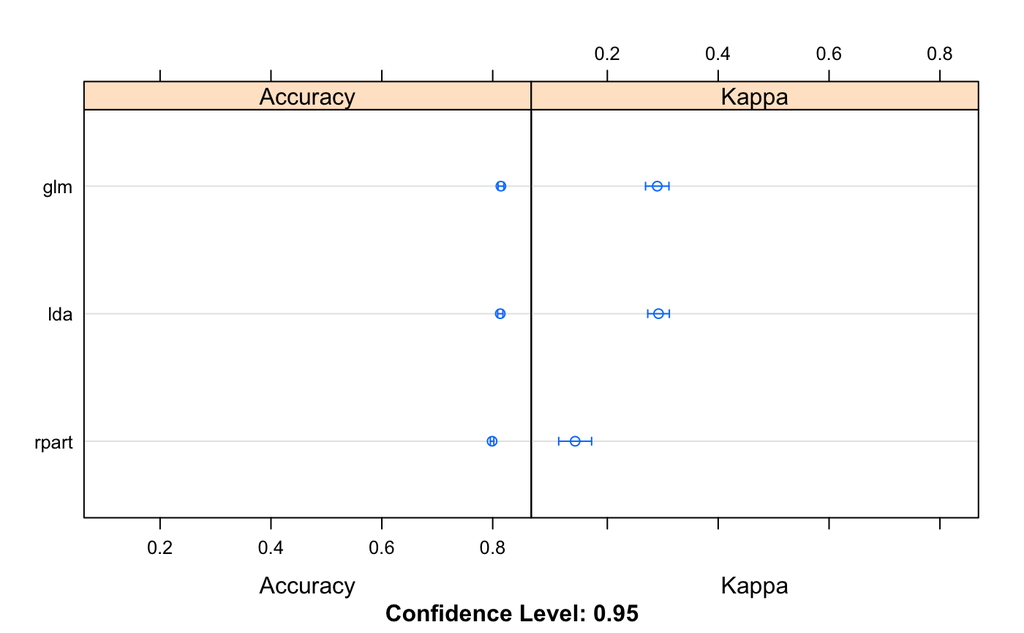

`r`r

# correlation between results

modelCor(results)

```
            lda     rpart       glm
lda   1.0000000 0.1656148 0.9283705
rpart 0.1656148 1.0000000 0.2025172
glm   0.9283705 0.2025172 1.0000000
```

`r`r splom(results)

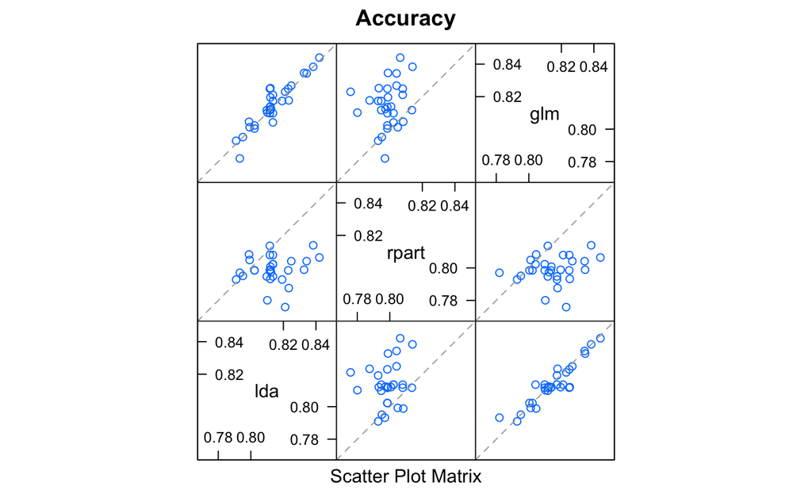

`r`r

# stack using glm

set.seed(123) stackControl <- trainControl(method=, number=10, repeats=3, savePredictions=TRUE, classProbs=TRUE) stack.glm <- caretStack(models, method=, metric=, trControl=stackControl) print(stack.glm)

[output not shown]

`r`r predict_stack = predict(stack.glm, newdata = test, type = ) table(test$Top100, predict_stack > 0.5)

```
     FALSE TRUE
  X0  1335   79
  X1   251  106
```

`r`r tableAccuracy(test$Top100, predict_stack > 0.5) # 0.8068888

```
[1] 0.8136646
```

`r`r tableTPR(test$Top100, predict_stack > 0.5) # 0.2577031

```
[1] 0.2969188
```

`r`r tableFPR(test$Top100, predict_stack > 0.5) # 0.05445545

```
[1] 0.05586987
```

`r`r # Calculate ROC curve rocr.stack.pred <- prediction(predict_stack, test$Top100) stackPerformance <- performance(rocr.stack.pred, , ) plot(logPerformance, colorize = TRUE) abline(0, 1)

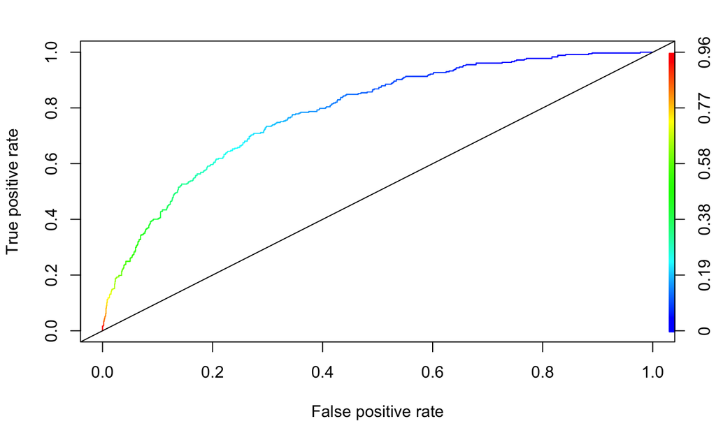

`r`r

as.numeric(performance(rocr.stack.pred, )@y.values) # AUC = 0.767919

```
[1] 0.7966771
```

# Model 9: Ridge Regression

`r`r set.seed(123)

# convert training data to matrix format

x <- model.matrix(Top100 ~ ., train) # convert class to numerical variable y <- ifelse(train$Top100==‘X1’,1,0)

# perform grid search to find optimal value of lambda

# family = binomial => logistic regression, alpha = 0 => ridge

# check docs to explore other type.measure options

cv.out <- cv.glmnet(x, y, alpha = 0, family = ‘binomial’, type.measure = ‘mse’) #plot result plot(cv.out)

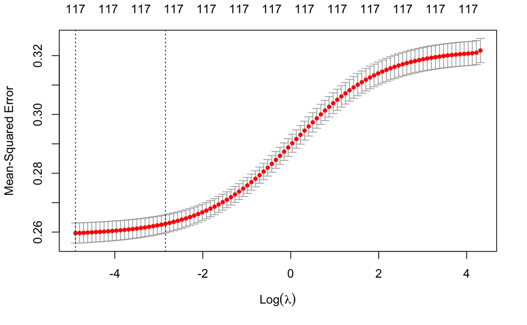

`r`r

# min value of lambda

lambda_min <- cv.out$lambda.min # best value of lambda lambda_1se <- cv.out$lambda.1se # regression coefficients coef(cv.out,s=lambda_1se)

```
119 x 1 sparse Matrix of class \dgCMatrix\
                            1
(Intercept)      -2.778239918
(Intercept)       .
Danceability      0.059610907
Energy           -0.055644163
Key.1             0.026624638
Key.2             0.028434010
Key.3            -0.059369499
Key.4             0.031494763
Key.5             0.065351468
Key.6            -0.098151932
Key.7             0.023654407
Key.8             0.239468818
Key.9             0.017694261
Key.10           -0.041887195
Key.11            0.056530999
Loudness          0.204338798
Mode.1            0.059847793
Speechiness      -0.061282287
Acousticness     -0.237050313
Instrumentalness -0.188198414
Liveness         -0.106406501
Valence           0.063759044
Tempo            -0.067624315
Duration          0.242975635
Time_Signature.3 -0.103901356
Time_Signature.4  0.104374650
Time_Signature.5  0.352419497
explicit.1        0.175811987
Genre.classical  -0.186100416
Genre.country     0.961793653
Genre.edm        -0.927430674
Genre.jazz       -0.786198620
Genre.metal      -0.171467742
Genre.pop         0.300012760
Genre.rap        -0.026871953
Genre.reggae     -0.309254253
Genre.rock       -0.371292233
away              0.134587869
```

[output cut: 66 more lines]

```
babi              0.061096011
hand              0.091711997
shit             -0.027048835
yeah             -0.016348517
wanna             0.040269213
said              0.093932405
heart            -0.009177699
good              0.040071602
que              -0.092752357
aint             -0.012023097
bitch            -0.018098293
man               0.056467715
money            -0.001659135
gotta             0.060691802
nigga            -0.035913922
```

`r`r # get test data x_test <- model.matrix(Top100 ~ ., test) # predict class, type=”class” ridge_prob <- predict(cv.out, newx = x_test, s = lambda_1se, type = ‘response’) #translate probabilities to predictions ridge_predict <- rep(‘X0’, nrow(test)) ridge_predict[ridge_prob>.5] <- ‘X1’

#confusion matrix table(pred=ridge_predict,true=test$Top100)

```
    true
pred   X0   X1
  X0 1360  292
  X1   54   65
```

`r`r tableAccuracy(test$Top100, ridge_predict) # 0.8051948

```
[1] 0.8046302
```

`r`r tableTPR(test$Top100, ridge_predict) # 0.1512605

```
[1] 0.1820728
```

`r`r tableFPR(test$Top100, ridge_predict) # 0.02970297

```
[1] 0.03818953
```

# Model 10: Lasso Regression

`r`r set.seed(123)

# convert training data to matrix format

x <- model.matrix(Top100 ~ ., train) # convert class to numerical variable y <- ifelse(train$Top100==‘X1’,1,0)

# perform grid search to find optimal value of lambda

# family = binomial => logistic regression, alpha = 1 => lasso

# check docs to explore other type.measure options

cv.out <- cv.glmnet(x, y, alpha = 1, family = ‘binomial’, type.measure = ‘mse’) #plot result plot(cv.out)

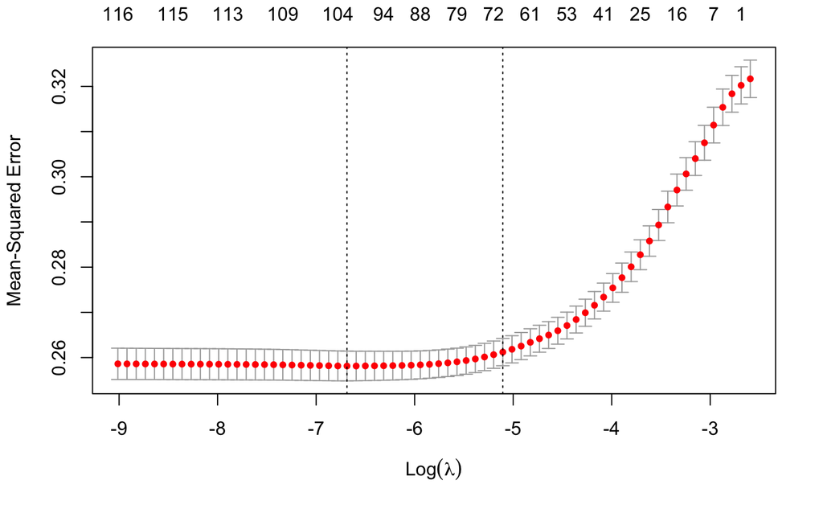

`r`r

# min value of lambda

lambda_min <- cv.out$lambda.min # best value of lambda lambda_1se <- cv.out$lambda.1se # regression coefficients coef(cv.out,s=lambda_1se)

```
119 x 1 sparse Matrix of class \dgCMatrix\
                             1
(Intercept)      -2.7018417641
(Intercept)       .
Danceability      0.0560138454
Energy           -0.1220315665
Key.1             .
Key.2             .
Key.3             .
Key.4             .
Key.5             .
Key.6             .
Key.7             .
Key.8             0.1718671894
Key.9             .
Key.10            .
Key.11            .
Loudness          0.2966304918
Mode.1            .
Speechiness       .
Acousticness     -0.3633365997
Instrumentalness -0.3773318131
Liveness         -0.1117344145
Valence           0.0597839198
Tempo            -0.0642457866
Duration          0.3393360675
Time_Signature.3  .
Time_Signature.4  .
Time_Signature.5  0.0048011947
explicit.1        0.1758210159
Genre.classical   .
Genre.country     1.4102410964
Genre.edm        -0.8495479091
Genre.jazz       -0.3517782028
Genre.metal       .
Genre.pop         0.5187711010
Genre.rap         .
Genre.reggae      .
Genre.rock       -0.2237184976
away              0.1232324530
```

[output cut: 66 more lines]

```
babi              0.0579832958
hand              0.0444998320
shit              .
yeah             -0.0010911181
wanna             0.0172512925
said              0.0710772725
heart             .
good              0.0093395916
que              -0.1910791735
aint              .
bitch             .
man               0.0324251856
money             .
gotta             0.0222332265
nigga            -0.0030367301
```

`r`r # get test data x_test <- model.matrix(Top100 ~ ., test) # predict class, type=”class” lasso_prob <- predict(cv.out, newx = x_test, s = lambda_1se, type = ‘response’) #translate probabilities to predictions lasso_predict <- rep(‘X0’, nrow(test)) lasso_predict[lasso_prob>.5] <- ‘X1’

#confusion matrix table(pred=lasso_predict,true=test$Top100)

```
    true
pred   X0   X1
  X0 1364  291
  X1   50   66
```

`r`r tableAccuracy(test$Top100, lasso_predict) # 0.8046302

```
[1] 0.8074534
```

`r`r tableTPR(test$Top100, lasso_predict) # 0.1708683

```
[1] 0.1848739
```

`r`r tableFPR(test$Top100, lasso_predict) # 0.03536068

```
[1] 0.03536068
```